# Predicting Hotel Reservations Cancellations

### Introduction

During the pandemic, hotels were forced to add full refund policies for reservations. The trend still stands three years later. The experience of trying to cancel any type of travel arrangement in 2020 has had a huge impact on consumer behavior. Today, many people will not book unless there is a free cancelation button. As a result of the free cancellation policies, rebooking activity has increased with canceling of existing reservations and booking of the same rooms as rates are slashed to secure occupancy. Hotels with low occupancy rates are particularly vulnerable to the change in the consumer. Data shows that higher guest engagement and personalization may result in lower cancellation and rebooking rates

### Goal

Hotel Delfino wants to target high-risk guests with a campaign of perks and discounts to lower cancellations and rebookings. To do so, executives need a method to predict if a guest will cancel their reservation.

## Analysis Table of Contents

### 1. Source Data

Dataset will be imported from the following link.

• Link: https://www.kaggle.com/datasets/ahsan81/hotel-reservations-classification-dataset

### 2. Initial Review of Data

```python
import pandas as pd
import seaborn as sns
import matplotlib.pyplot as plt



# Read in csv
df=pd.read_csv('Hotel Reservations.csv')

# Save the number of rows columns as a tuple
rows_and_cols = df.shape
print('There are {} rows and {} columns.\n'.format(
    rows_and_cols[0], rows_and_cols[1]))

# Generate an overview of the DataFrame
df_info = df.info()
print(df_info)
```

```
There are 36275 rows and 19 columns.

<class 'pandas.core.frame.DataFrame'>
RangeIndex: 36275 entries, 0 to 36274
Data columns (total 19 columns):
 #   Column                                Non-Null Count  Dtype
---  ------                                --------------  -----
 0   Booking_ID                            36275 non-null  object
 1   no_of_adults                          36275 non-null  int64
 2   no_of_children                        36275 non-null  int64
 3   no_of_weekend_nights                  36275 non-null  int64
 4   no_of_week_nights                     36275 non-null  int64
 5   type_of_meal_plan                     36275 non-null  object
 6   required_car_parking_space            36275 non-null  int64
 7   room_type_reserved                    36275 non-null  object
 8   lead_time                             36275 non-null  int64
 9   arrival_year                          36275 non-null  int64
 10  arrival_month                         36275 non-null  int64
 11  arrival_date                          36275 non-null  int64
 12  market_segment_type                   36275 non-null  object
 13  repeated_guest                        36275 non-null  int64
 14  no_of_previous_cancellations          36275 non-null  int64
 15  no_of_previous_bookings_not_canceled  36275 non-null  int64
 16  avg_price_per_room                    36275 non-null  float64
 17  no_of_special_requests                36275 non-null  int64
 18  booking_status                        36275 non-null  object
dtypes: float64(1), int64(13), object(5)
memory usage: 5.3+ MB
None
```

```python
#null values
df.isna().sum()

#duplicated values
df.duplicated().unique()
```

```
array([False])
```

```python
#balance of binary target variable
df_cat['booking_status'].value_counts(normalize=True)
```

```
Not_Canceled    0.672364
Canceled        0.327636
Name: booking_status, dtype: float64
```

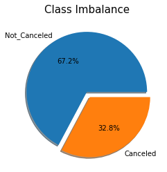

```python
df.value_counts('booking_status').plot(kind='pie',explode=[0,.1], shadow=True, autopct='%1.1f%%')
plt.title('Class Imbalance', fontsize=15)
plt.ylabel('')
plt.show()
```

### 3. Data Manipulation

```python
#Extract continuous variable
df_cont=df[['no_of_adults','no_of_children', 'no_of_week_nights','no_of_weekend_nights', 'lead_time','no_of_previous_cancellations','no_of_previous_bookings_not_canceled','avg_price_per_room','no_of_special_requests']]

#Extract categorical variables
df_cat=df[['booking_status','room_type_reserved','type_of_meal_plan','market_segment_type']]
```

### 4. Data Exploration

```python
#distributions of room price and lead time
df_col=df[['lead_time','avg_price_per_room']].columns
```

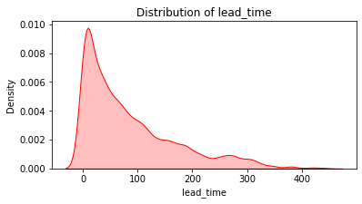

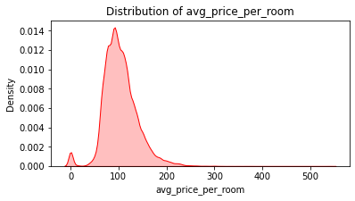

```python
def plot_dist(df,cont):
    for x in cont:
        plt.figure(figsize=(6,3))
        sns.kdeplot(df[x], legend=False, color="red", shade=True)
        plt.title("Distribution of "+x)
        plt.show()

plot_dist(df,df_col)
```

```python
df_cont.describe()
```

|  | no_of_adults | no_of_children | no_of_week_nights | no_of_weekend_nights | lead_time | no_of_previous_cancellations | no_of_previous_bookings_not_canceled | avg_price_per_room | no_of_special_requests |
| --- | --- | --- | --- | --- | --- | --- | --- | --- | --- |
| count | 36275.000000 | 36275.000000 | 36275.000000 | 36275.000000 | 36275.000000 | 36275.000000 | 36275.000000 | 36275.000000 | 36275.000000 |
| mean | 1.844962 | 0.105279 | 2.204300 | 0.810724 | 85.232557 | 0.023349 | 0.153411 | 103.423539 | 0.619655 |
| std | 0.518715 | 0.402648 | 1.410905 | 0.870644 | 85.930817 | 0.368331 | 1.754171 | 35.089424 | 0.786236 |
| min | 0.000000 | 0.000000 | 0.000000 | 0.000000 | 0.000000 | 0.000000 | 0.000000 | 0.000000 | 0.000000 |
| 25% | 2.000000 | 0.000000 | 1.000000 | 0.000000 | 17.000000 | 0.000000 | 0.000000 | 80.300000 | 0.000000 |
| 50% | 2.000000 | 0.000000 | 2.000000 | 1.000000 | 57.000000 | 0.000000 | 0.000000 | 99.450000 | 0.000000 |
| 75% | 2.000000 | 0.000000 | 3.000000 | 2.000000 | 126.000000 | 0.000000 | 0.000000 | 120.000000 | 1.000000 |
| max | 4.000000 | 10.000000 | 17.000000 | 7.000000 | 443.000000 | 13.000000 | 58.000000 | 540.000000 | 5.000000 |

```python
df_cont.agg(['median','max','min','count'],axis=0).transpose()
```

|  | median | max | min | count |
| --- | --- | --- | --- | --- |
| no_of_adults | 2.00 | 4.0 | 0.0 | 36275.0 |
| no_of_children | 0.00 | 10.0 | 0.0 | 36275.0 |
| no_of_week_nights | 2.00 | 17.0 | 0.0 | 36275.0 |
| no_of_weekend_nights | 1.00 | 7.0 | 0.0 | 36275.0 |
| lead_time | 57.00 | 443.0 | 0.0 | 36275.0 |
| no_of_previous_cancellations | 0.00 | 13.0 | 0.0 | 36275.0 |
| no_of_previous_bookings_not_canceled | 0.00 | 58.0 | 0.0 | 36275.0 |
| avg_price_per_room | 99.45 | 540.0 | 0.0 | 36275.0 |
| no_of_special_requests | 0.00 | 5.0 | 0.0 | 36275.0 |

```python
#feature correlation heat map
df.corr()
```

|  | no_of_adults | no_of_children | no_of_weekend_nights | no_of_week_nights | required_car_parking_space | lead_time | arrival_year | arrival_month | arrival_date | repeated_guest | no_of_previous_cancellations | no_of_previous_bookings_not_canceled | avg_price_per_room | no_of_special_requests |
| --- | --- | --- | --- | --- | --- | --- | --- | --- | --- | --- | --- | --- | --- | --- |
| no_of_adults | 1.000000 | -0.019787 | 0.103316 | 0.105622 | 0.011429 | 0.097287 | 0.076719 | 0.021841 | 0.026338 | -0.192277 | -0.047426 | -0.119166 | 0.296886 | 0.189401 |
| no_of_children | -0.019787 | 1.000000 | 0.029478 | 0.024398 | 0.034244 | -0.047091 | 0.045983 | -0.003076 | 0.025482 | -0.036348 | -0.016390 | -0.021189 | 0.337728 | 0.124486 |
| no_of_weekend_nights | 0.103316 | 0.029478 | 1.000000 | 0.179577 | -0.031111 | 0.046595 | 0.055357 | -0.009894 | 0.027304 | -0.067107 | -0.020690 | -0.026312 | -0.004525 | 0.060593 |
| no_of_week_nights | 0.105622 | 0.024398 | 0.179577 | 1.000000 | -0.048784 | 0.149650 | 0.032672 | 0.037376 | -0.009305 | -0.099764 | -0.030080 | -0.049344 | 0.022753 | 0.045994 |
| required_car_parking_space | 0.011429 | 0.034244 | -0.031111 | -0.048784 | 1.000000 | -0.066445 | 0.015684 | -0.015505 | -0.000037 | 0.110909 | 0.027106 | 0.063810 | 0.061304 | 0.087922 |
| lead_time | 0.097287 | -0.047091 | 0.046595 | 0.149650 | -0.066445 | 1.000000 | 0.143439 | 0.136814 | 0.006479 | -0.135984 | -0.045723 | -0.078137 | -0.062596 | -0.101645 |
| arrival_year | 0.076719 | 0.045983 | 0.055357 | 0.032672 | 0.015684 | 0.143439 | 1.000000 | -0.339689 | 0.018849 | -0.018175 | 0.003919 | 0.026422 | 0.178605 | 0.053205 |
| arrival_month | 0.021841 | -0.003076 | -0.009894 | 0.037376 | -0.015505 | 0.136814 | -0.339689 | 1.000000 | -0.042780 | 0.000341 | -0.038615 | -0.010718 | 0.054423 | 0.110552 |
| arrival_date | 0.026338 | 0.025482 | 0.027304 | -0.009305 | -0.000037 | 0.006479 | 0.018849 | -0.042780 | 1.000000 | -0.015949 | -0.012542 | -0.001498 | 0.017898 | 0.018352 |
| repeated_guest | -0.192277 | -0.036348 | -0.067107 | -0.099764 | 0.110909 | -0.135984 | -0.018175 | 0.000341 | -0.015949 | 1.000000 | 0.390810 | 0.539156 | -0.174900 | -0.011820 |
| no_of_previous_cancellations | -0.047426 | -0.016390 | -0.020690 | -0.030080 | 0.027106 | -0.045723 | 0.003919 | -0.038615 | -0.012542 | 0.390810 | 1.000000 | 0.468147 | -0.063340 | -0.003317 |
| no_of_previous_bookings_not_canceled | -0.119166 | -0.021189 | -0.026312 | -0.049344 | 0.063810 | -0.078137 | 0.026422 | -0.010718 | -0.001498 | 0.539156 | 0.468147 | 1.000000 | -0.113684 | 0.027377 |
| avg_price_per_room | 0.296886 | 0.337728 | -0.004525 | 0.022753 | 0.061304 | -0.062596 | 0.178605 | 0.054423 | 0.017898 | -0.174900 | -0.063340 | -0.113684 | 1.000000 | 0.184381 |
| no_of_special_requests | 0.189401 | 0.124486 | 0.060593 | 0.045994 | 0.087922 | -0.101645 | 0.053205 | 0.110552 | 0.018352 | -0.011820 | -0.003317 | 0.027377 | 0.184381 | 1.000000 |

```python
#features by booking status
df.groupby('booking_status')[['no_of_adults','no_of_children', 'no_of_week_nights','no_of_weekend_nights', 'lead_time','no_of_previous_cancellations','no_of_previous_bookings_not_canceled','avg_price_per_room','no_of_special_requests']].mean().round(2).transpose()
```

| booking_status | Canceled | Not_Canceled |
| --- | --- | --- |
| no_of_adults | 1.91 | 1.81 |
| no_of_children | 0.12 | 0.10 |
| no_of_week_nights | 2.39 | 2.11 |
| no_of_weekend_nights | 0.89 | 0.77 |
| lead_time | 139.22 | 58.93 |
| no_of_previous_cancellations | 0.01 | 0.03 |
| no_of_previous_bookings_not_canceled | 0.00 | 0.23 |
| avg_price_per_room | 110.59 | 99.93 |
| no_of_special_requests | 0.33 | 0.76 |

```python
#count by booking_status
df_col2=df[['repeated_guest','type_of_meal_plan','market_segment_type','room_type_reserved','arrival_month']].columns
df_col2
```

```
Index(['repeated_guest', 'type_of_meal_plan', 'market_segment_type',
       'room_type_reserved', 'arrival_month'],
      dtype='object')
```

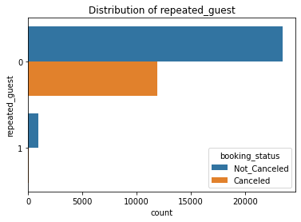

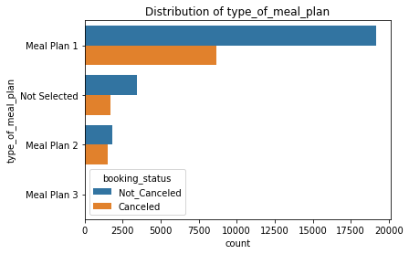

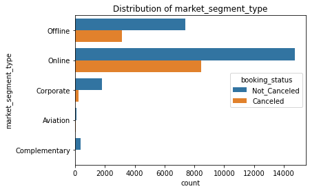

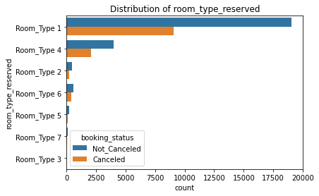

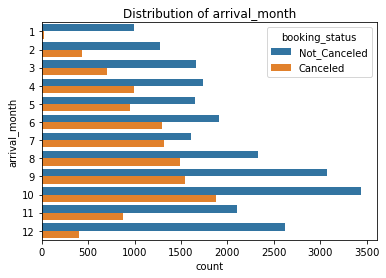

```python
#countplots
def plot_count(cont):
    for z in cont:
     sns.countplot(y=z,data=df,hue='booking_status')
     plt.title("Distribution of "+z)
     plt.show()
plot_count(df_col2)
```

### Initial Findings

- A large majority of guests do not cancel their reservations.
- The typical guest that has the highest probability to keep their reservation: books their travel plans under two months in advance, is a repeat guest, books during the Christmas holidays, and is in town for work.
- The guests most likely to cancel: book well in advance, book online with a more expensive room, have never stayed at the hotel, and arrive during the summer months.

### 5. Preprocessing Methods

```python
#create target variable
target=df_cat['booking_status']
df_cat=df_cat.drop('booking_status', axis=1)

#Inspect categorical features
print(df_cat['room_type_reserved'].unique())
print(df_cat['type_of_meal_plan'].unique())
print(df_cat['market_segment_type'].unique())
```

```
['Room_Type 1' 'Room_Type 4' 'Room_Type 2' 'Room_Type 6' 'Room_Type 5'
 'Room_Type 7' 'Room_Type 3']
['Meal Plan 1' 'Not Selected' 'Meal Plan 2' 'Meal Plan 3']
['Offline' 'Online' 'Corporate' 'Aviation' 'Complementary']
```

```python
#transform categorical to binary because machine learning models need numbers
df_cat=pd.get_dummies(df_cat)
```

```python
#transform target to binary
target=target.apply(lambda val: 1 if val == 'Canceled' else 0)
target
```

```
0        0
1        0
2        1
3        1
4        1
        ..
36270    0
36271    1
36272    0
36273    1
36274    0
Name: booking_status, Length: 36275, dtype: int64
```

```python
#Combine converted categorical feat with cont feat
dfx=pd.concat([df_cont,df_cat],axis=1)
dfx.shape, target.shape
```

```
((36275, 25), (36275,))
```

```python
#train_test_split
from sklearn.model_selection import train_test_split



x_train, x_test, y_train, y_test =train_test_split(dfx, target, test_size=.3, random_state=123)
```

```python
print(y_test.value_counts(normalize=True))
print(X_test.value_counts(normalize=True))
```

[output not shown]

## 6. Build Machine Learning Models

[output not shown]

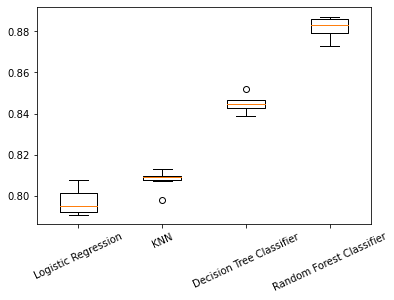

```python
# Import
from sklearn.linear_model import LogisticRegression
from sklearn.tree import DecisionTreeClassifier
from sklearn.neighbors import KNeighborsClassifier
from sklearn.model_selection import KFold
from sklearn.model_selection import cross_val_score
from sklearn.ensemble import RandomForestClassifier


# Create models dictionary
models = {"Logistic Regression": LogisticRegression(), "KNN": KNeighborsClassifier(),\
          "Decision Tree Classifier": DecisionTreeClassifier(),\
          "Random Forest Classifier": RandomForestClassifier()}
results = []

# Loop through the models' values
for model in models.values():

  # Instantiate a KFold object
  kf = KFold(n_splits=6, random_state=12, shuffle=True)

  # Perform cross-validation
  cv_results = cross_val_score(model, X_train, y_train, cv=kf)
  results.append(cv_results)
plt.boxplot(results, labels=models.keys())
plt.xticks(rotation = 25)
plt.show()
```

```python
#test data accuracy
from sklearn.metrics import accuracy_score
rf_pred=rf.predict(x_test)
print(accuracy_score(y_test, rf_pred))
```

```
0.8629054488652026
```

## 7. Model Evaluation

```python
from sklearn.metrics import confusion_matrix

# Confusion Matrix
print(confusion_matrix(y_test,rf_pred))
```

```
[[6897  494]
 [ 998 2494]]
```

```python
#AUC for imbalance target variable
#train data

from sklearn.metrics import roc_curve, auc

class_probabilities = rf.predict_proba(x_test)
preds = class_probabilities[:, 1]

fpr, tpr, threshold = roc_curve(y_test, preds)
roc_auc = auc(fpr, tpr)

# Printing AUC
print(f"AUC for rf train classifier is: {roc_auc}")

#test_data

class_probabilities = rf.predict_proba(X_train)
preds = class_probabilities[:, 1]

fpr, tpr, threshold = roc_curve(y_train, preds)
roc_auc = auc(fpr, tpr)

# Printing AUC
print(f"AUC for rf test classifier is: {roc_auc}")
```

```
AUC for rf train classifier is: 0.9168524325194738
AUC for rf test classifier is: 0.9336417046055658
```

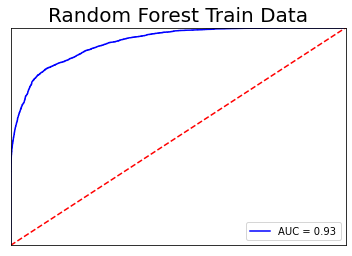

[figure not shown]

```python
from matplotlib import pyplot as plt
plt.figure()
plt.title('Random Forest Train Data', fontsize=20)
plt.plot(fpr, tpr, 'b', label = 'AUC = %0.2f' % roc_auc)
plt.legend(loc = 'lower right')
plt.plot([0, 1], [0, 1],'r--')
plt.xlim([0, 1])
plt.ylim([0, 1])
plt.xticks([])
plt.yticks([])
plt.show()
plt.figure()
plt.title('Random Forest Test Data', fontsize=20)
plt.plot(fpr, tpr, 'b', label = 'AUC = %0.2f' % roc_auc)
plt.legend(loc = 'lower right', fontsize=15)
plt.plot([0, 1], [0, 1],'r--')
plt.xlim([0, 1])
plt.ylim([0, 1])

plt.show()
```

### Conclusion

#### Next Steps

- The most accurate method was an esemble training method, similar methods such as bagging or boosting may provide better results
- standardization methods can be used improve overall accuracy in logistic regression algorithm
- Tuning hyperparameters can also potentially yield better results through methods such as gridsearch or randomizedsearch